# Project2

Nicole Levin

2022-09-29

# Introduction

This document is a vignette that describes pulling data from an API and performing some exploratory data analysis based on those results. This vignette will utilze the Spoonacular food API. More information about this API can be found [here](https://spoonacular.com/food-api) In this vignette, we will be building some functions to interact with the API and doing some exploratory data analysis based on some example search results.

# Required Packages

The following packages are required for interacting with the functions in this vignette: - httr - dplyr - jsonlite - tidyverse

First, we will load the required packages

```r
#Load libraries
library(httr)
library(dplyr)
library(jsonlite)
library(tidyverse)
```

# Building Search Functions

Thare are two functions that have been created to allow the user to make a search from the API. The first is called “ingredient_search” and it allows the user to select an ingredient and a number of results to return. The function will then provide an output data frame with many points of information for each of the recipes. The function works by first searching for recipes with the ingredient. The ID numbers that the API identifies these recipes by are then plugged into a second search to get a combination of quantitative and categorical data including health scores, aggregate likes, whether a dish is vegetarian, whether it is gluten free, and whether it is dairy free. Full search code is as follows:

```r
#User options for search. Can input: (1)ingredient for search, (2)Number of results
ingredient_search <- function(ingredient, number=10){
  ingredient <- tolower(ingredient)
  search_url <- "https://spoonacular-recipe-food-nutrition-v1.p.rapidapi.com/recipes/findByIngredients"
  queryString <- list(
  ingredients = ingredient,
  number = number)
search_result <- VERB("GET", search_url, add_headers('X-RapidAPI-Key' = '73a2057416msh633772bf8275edfp1b3775jsn7e44cc5cb98d', 'X-RapidAPI-Host' = 'spoonacular-recipe-food-nutrition-v1.p.rapidapi.com'), query = queryString, content_type("application/octet-stream"))
  parsed_search_result <- fromJSON(rawToChar(search_result$content))
  id_list <- paste(as.character(parsed_search_result$id), collapse=",")
bulk_url <- "https://spoonacular-recipe-food-nutrition-v1.p.rapidapi.com/recipes/informationBulk"
queryString <- list(ids = id_list)
bulk_search <- VERB("GET", bulk_url, add_headers('X-RapidAPI-Key' = '73a2057416msh633772bf8275edfp1b3775jsn7e44cc5cb98d', 'X-RapidAPI-Host' = 'spoonacular-recipe-food-nutrition-v1.p.rapidapi.com'), query = queryString, content_type("application/octet-stream"))
  parsed_bulk_search <- fromJSON(rawToChar(bulk_search$content))
  results_df <- as_tibble(parsed_bulk_search) %>% select(id, title, glutenFree, dairyFree, vegetarian, aggregateLikes, healthScore, weightWatcherSmartPoints, sourceName, pricePerServing, readyInMinutes)
  combined_results <- results_df %>% mutate(WW_category = if_else(weightWatcherSmartPoints <10, 1, if_else(weightWatcherSmartPoints <20, 2, 3)))
  factor(combined_results$WW_category, levels = c(1, 2, 3), labels = c("low", "medium", "high"))
return(combined_results)
}

#Run a test
ingredient_test <- ingredient_search(ingredient="cherry", number=50)
ingredient_test
```

```
## # A tibble: 50 × 12
##         id title      glutenFree dairyFree vegetarian aggregateLikes healthScore
##      <int> <chr>      <lgl>      <lgl>     <lgl>               <int>       <int>
##  1  799316 Black Che… TRUE       TRUE      FALSE                  10           0
##  2   50161 Jell-o Mo… TRUE       FALSE     TRUE                    1           2
##  3  779475 Black Che… TRUE       TRUE      TRUE                  167           0
##  4   50105 Cherry Mo… TRUE       TRUE      TRUE                   37           1
##  5   52755 Yellow Ch… TRUE       TRUE      TRUE                   26           2
##  6 1065961 Cherry Pr… TRUE       TRUE      TRUE                    1           7
##  7  405122 Bing Cher… TRUE       FALSE     TRUE                    0           2
##  8  525223 Dark Choc… FALSE      TRUE      FALSE               26141           3
##  9  524954 Root Beer… TRUE       TRUE      FALSE                2592           1
## 10  539027 Quick and… TRUE       FALSE     TRUE                 1491           5
## # … with 40 more rows, and 5 more variables: weightWatcherSmartPoints <int>,
## #   sourceName <chr>, pricePerServing <dbl>, readyInMinutes <int>,
## #   WW_category <dbl>
```

The second function is called “calorie_search” and it allows the user to select a minimum number of calories, maximum number of calories, whether they want random results or ordered, and what number of results they want. This function has default values for all variables, so they do not all have to be specified for the search to execute. It works in a similar fashion, where the initial query gets the list of ID numbers to be used in a second query to get more data. In this case though, the initial nutrition search based on calories gives us some variables like number of calories, grams of carbohydrates, grams of protein, and grams of fat that we can bring into the final data set too. The full code of the function is as follows:

```r
#This function is a search by calories. User options are (1)Minimum calories, (2)Maximum calories, (3)Whether we want a random set of results or the first ones alphabetically, and a number of results. All of these have defaults, so the user can specify nothing and still get a result.
calorie_search <- function(min_calories=0, max_calories=5000, random=FALSE, number=10){
  min_calories <- as.character(min_calories)
  max_calories <- as.character(max_calories)
  number <- as.character(number)
  search_url <- "https://spoonacular-recipe-food-nutrition-v1.p.rapidapi.com/recipes/findByNutrients"
  if(random==FALSE){
    queryString <- list(minCalories = min_calories, maxCalories = max_calories, number=number)}
  else {queryString <- list(minCalories = min_calories, maxCalories = max_calories, random = TRUE)}
  search_result <- VERB("GET", search_url, add_headers('X-RapidAPI-Key' = '73a2057416msh633772bf8275edfp1b3775jsn7e44cc5cb98d', 'X-RapidAPI-Host' = 'spoonacular-recipe-food-nutrition-v1.p.rapidapi.com'), query = queryString, content_type("application/octet-stream"))
  parsed_search_result <- fromJSON(rawToChar(search_result$content))
  id_list <- paste(as.character(parsed_search_result$id), collapse=",")
  bulk_url <- "https://spoonacular-recipe-food-nutrition-v1.p.rapidapi.com/recipes/informationBulk"
queryString <- list(ids = id_list)
bulk_search <- VERB("GET", bulk_url, add_headers('X-RapidAPI-Key' = '73a2057416msh633772bf8275edfp1b3775jsn7e44cc5cb98d', 'X-RapidAPI-Host' = 'spoonacular-recipe-food-nutrition-v1.p.rapidapi.com'), query = queryString, content_type("application/octet-stream"))
  parsed_bulk_search <- fromJSON(rawToChar(bulk_search$content))
  results_df <- as_tibble(parsed_bulk_search) %>% select(id, title, glutenFree, dairyFree, vegetarian, aggregateLikes, healthScore, weightWatcherSmartPoints, sourceName, pricePerServing, readyInMinutes)
  results_df <- results_df %>% mutate(WW_category = if_else(weightWatcherSmartPoints <10, 1, if_else(weightWatcherSmartPoints <20, 2, 3)))
  factor(results_df$WW_category, levels = c(1, 2, 3), labels = c("low", "medium", "high"))
  combined_results <- as_tibble(c(results_df, parsed_search_result[,3:8]))
  return(combined_results)
}

calorie_test <- calorie_search(min_calories = 100, max_calories = 500, number=50)
calorie_test
```

```
## # A tibble: 50 × 18
##        id title       glutenFree dairyFree vegetarian aggregateLikes healthScore
##     <int> <chr>       <lgl>      <lgl>     <lgl>               <int>       <int>
##  1  17281 Spicy Tuna… TRUE       TRUE      FALSE                   5          71
##  2  30338 Spanish-St… TRUE       TRUE      FALSE                   0         100
##  3  51843 Lemon-blue… FALSE      FALSE     TRUE                   25           2
##  4  58965 Mango & Ra… FALSE      FALSE     TRUE                   30           1
##  5  66226 Grapefruit… FALSE      FALSE     TRUE                    0           0
##  6  70450 Apple Pie … TRUE       FALSE     FALSE                 668           1
##  7  90629 Baked Appl… TRUE       FALSE     TRUE                    0           0
##  8  94853 Cantaloupe… TRUE       FALSE     TRUE                    0          22
##  9 105012 Grilled Zu… TRUE       FALSE     FALSE                   1          11
## 10 109236 Baby Artic… TRUE       TRUE      FALSE                   0           5
## # … with 40 more rows, and 11 more variables: weightWatcherSmartPoints <int>,
## #   sourceName <chr>, pricePerServing <dbl>, readyInMinutes <int>,
## #   WW_category <dbl>, image <chr>, imageType <chr>, calories <int>,
## #   protein <chr>, fat <chr>, carbs <chr>
```

# Variable Creation

Both of these searches included an output variable of “WW_category” This variable did not exist in the source data and had to be created using the Weight Watchers Smart Points values. The categories utilized are:

1. Low: less than 10
2. Medium: 10 to less than 20
3. High: 20 or greater

“if_else” statements are used to create the new variable based on this categorization.

# Exploratory Data Analysis

Now that we have set up our functions and run some test searches, we can do some exploratory data analysis of the results.First, let’s look at some contingency tables and bar plots of Weight Watcher points categories, grouped by vegeterian to see if vegetarian results tend to be lower point values.

```r
#Create contingency table from calorie test results
table(calorie_test$WW_category, calorie_test$vegetarian, dnn=c("WW Category", "vegetarian"))
```

```
##            vegetarian
## WW Category FALSE TRUE
##           1    23   12
##           2     8    6
##           3     1    0
```

```r
#Create contingency table for ingredient test results
table(ingredient_test$WW_category, ingredient_test$vegetarian, dnn=c("WW Category", "vegetarian"))
```

```
##            vegetarian
## WW Category FALSE TRUE
##           1    15   23
##           2     3    4
##           3     2    3
```

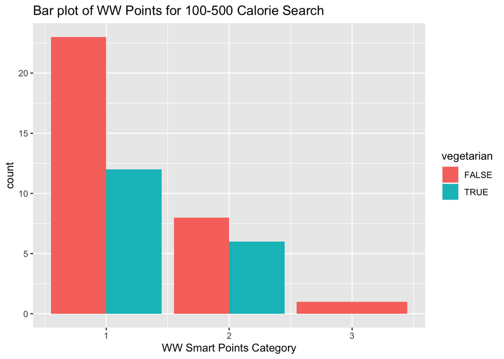

```r
#Plot my tests as bar plots of Weight Watchers category grouped by vegetarian.
g <- ggplot(calorie_test, aes(x=WW_category))
g + geom_bar(aes(fill=vegetarian), position="dodge") +
  labs(title="Bar plot of WW Points for 100-500 Calorie Search", x="WW Smart Points Category")
```

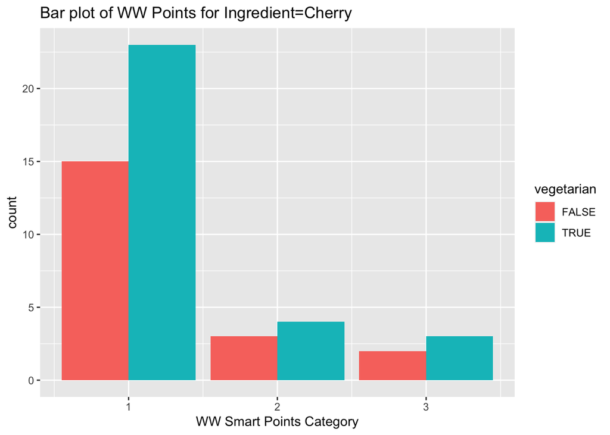

```r
g <- ggplot(ingredient_test, aes(x=WW_category))
g + geom_bar(aes(fill=vegetarian), position="dodge") +
  labs(title="Bar plot of WW Points for Ingredient=Cherry", x="WW Smart Points Category")
```

The most noticeable result here is that we get many more vegetarian results with our fruit ingredient choice vs. a calorie-based search.